# Predicting 2018 CFB Games

2022-08-21

# What is this?

This page displays predictions for games in the 2018 CFB season. These predictions come from a model built on historical college football play by play and game data in order to simulate upcoming games. All data is from collegefootballdata.com.

# 1 Week 15 Predictions

| Season | Week | Quality | Home | Away | Pr(HomeWin) | Prediction | Result | Correct | correct |
| --- | --- | --- | --- | --- | --- | --- | --- | --- | --- |
| 2018 | 15 | 50 | Army | Navy | 0.842 | Army by 17 |  |  |  |

# 2 Results Through Week 14

How has the model performed so far in2018?

## 2.1 Assessment

The model predicts the probability that the home team will win and their expected margin of victory (or defeat). I assess the model’s performance by assessing the accuracy of its predictions (win/loss), the logloss of its probabilities, and the mean absolute error of the margin.

| Season | Week | N | Outcome Accuracy | Outcome LogLoss | Margin MAE |
| --- | --- | --- | --- | --- | --- |
| 2018 | 1 | 88 | 0.82 | 0.41 | 16.4 |
| 2018 | 2 | 78 | 0.78 | 0.38 | 15.2 |
| 2018 | 3 | 66 | 0.79 | 0.43 | 14.3 |
| 2018 | 4 | 62 | 0.76 | 0.46 | 13.0 |
| 2018 | 5 | 58 | 0.76 | 0.47 | 11.8 |
| 2018 | 6 | 56 | 0.73 | 0.54 | 13.5 |
| 2018 | 7 | 55 | 0.69 | 0.57 | 14.5 |
| 2018 | 8 | 55 | 0.82 | 0.44 | 12.8 |
| 2018 | 9 | 56 | 0.54 | 0.67 | 13.8 |
| 2018 | 10 | 62 | 0.68 | 0.54 | 14.2 |
| 2018 | 11 | 62 | 0.84 | 0.46 | 11.8 |
| 2018 | 12 | 66 | 0.82 | 0.39 | 13.6 |
| 2018 | 13 | 64 | 0.72 | 0.55 | 14.4 |
| 2018 | 14 | 9 | 0.78 | 0.47 | 14.4 |
| Season Average: |  |  | 0.75 | 0.48 | 13.9 |

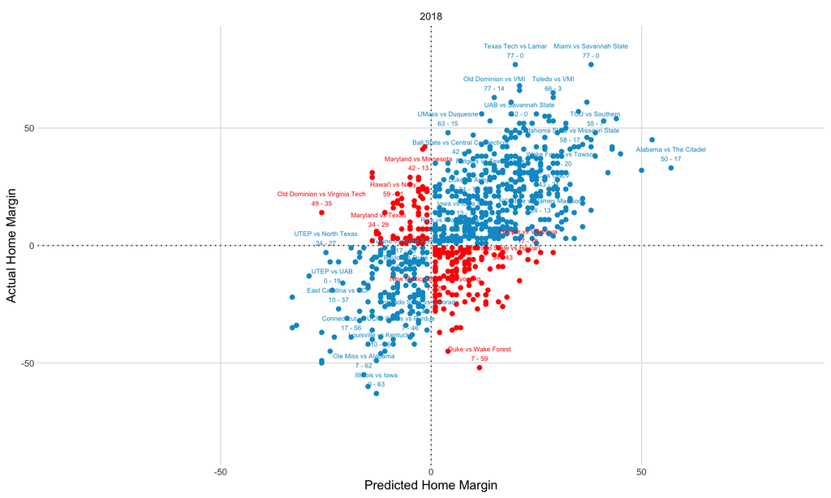

## 2.2 Results

| Season | Week | Quality | Home | Away | Pr(HomeWin) | Prediction | Result | Correct | correct |
| --- | --- | --- | --- | --- | --- | --- | --- | --- | --- |
| 2018 | 14 | 86 | Washington | Utah | 0.628 | Washington by 5 | Washington by 7 | Yes | 1 |
| 2018 | 14 | 74 | Boise State | Fresno State | 0.675 | Boise State by 8 | Fresno State by 3 | No | 0 |
| 2018 | 14 | 62 | California | Stanford | 0.406 | Stanford by 5 | Stanford by 10 | Yes | 1 |
| 2018 | 14 | 53 | Virginia Tech | Marshall | 0.530 | Virginia Tech by 1 | Virginia Tech by 21 | Yes | 1 |
| 2018 | 14 | 52 | Middle Tennessee | UAB | 0.678 | Middle Tennessee by 8 | UAB by 2 | No | 0 |
| 2018 | 14 | 44 | NC State | East Carolina | 0.946 | NC State by 28 | NC State by 55 | Yes | 1 |
| 2018 | 14 | 44 | Iowa State | Drake | 0.970 | Iowa State by 32 | Iowa State by 3 | Yes | 1 |
| 2018 | 14 | 37 | South Carolina | Akron | 0.963 | South Carolina by 29.5 | South Carolina by 25 | Yes | 1 |
| 2018 | 14 | 19 | Liberty | Norfolk State | 0.798 | Liberty by 14 | Liberty by 35 | Yes | 1 |
| 2018 | 13 | 94 | Ohio State | Michigan | 0.599 | Ohio State by 4 | Ohio State by 23 | Yes | 1 |

[output cut: 827 more lines]

# 3 Predicting the Rest of the Season

For example, we simulate the entire season before any games are played by simulating week two based on the (simulated) results of week one, then simulating week three based on the (simulated) results from week two. As a result, predictions for future weeks tend to be less accurate than predictions made one week in advance and are likely to change as we get closer to the actual game.

| Season | Week | Quality | Home | Away | Pr(HomeWin) | Prediction | Result | Correct | correct |
| --- | --- | --- | --- | --- | --- | --- | --- | --- | --- |